# 인공지능의 원리와 문제해결

컴퓨팅적 사고와 논리적 문제해결

유한대학교

## 인공지능과 머신러닝

- **인공지능**: 예측, 구분, 판단처럼 지능이 필요한 일을 컴퓨터가 수행하도록 만드는 기술입니다.
- **머신러닝**: 자료에서 입력과 결과 사이의 규칙을 학습하는, 인공지능의 구현 방법입니다. 딥러닝도 머신러닝의 한 방법입니다.

학습 단계

학습 자료입력과 정답의 쌍

→

학습 알고리즘규칙을 계산

→

모델학습한 규칙을 저장

예측 단계

새로운 입력정답을 모르는 자료

→

모델저장한 규칙을 적용

→

예측 결과숫자 또는 범주

## 머신러닝의 학습 방식

| 종류 | 학습에 쓰는 자료 | 학습의 목표 | 예 |
| --- | --- | --- | --- |
| 지도학습 | 입력과 정답 | 입력에서 정답을 예측하는 규칙 | 회귀(정답이 숫자), 분류(정답이 범주) |
| 비지도학습 | 입력만(정답 없음) | 자료의 구조와 비슷한 집단 발견 | 군집화, 차원 축소 |
| 강화학습 | 행동에 대한 보상 | 보상을 최대화하는 행동 전략 | 바둑, 게임, 로봇 제어 |

이번 강의는 지도학습의 회귀를 다룹니다.

## 머신러닝의 절차

1 문제 정의입력·목표 변수, 평가 지표

→

2 자료 준비표 구성, 학습용·평가용 분할

→

3 모델 학습모델 선택, fit()

→

4 모델 평가predict(), 오차 계산

→

5 성능 개선입력·모델·설정 변경

→

6 예측과 활용새 입력 예측

Géron, *Hands-On Machine Learning*, Appendix A · scikit-learn User Guide

## 예측 문제의 정의

1 문제 정의2 자료 준비3 모델 학습4 모델 평가5 성능 개선6 예측과 활용

| 항목 | 내용 |
| --- | --- |
| 질문 | 한 매장에서 한 시간의 주문 건수와 직원 수를 알 때 평균 대기시간은 몇 분인가? |
| 문제의 종류 | 회귀 (맞히려는 값이 숫자) |
| 입력 변수 | 주문 건수 `orders`, 직원 수 `staff` |
| 목표 변수 | 평균 대기시간 `wait` (분) |
| 평가 지표 | 평균 절대 오차 |

## 자료의 집계

1 문제 정의2 자료 준비3 모델 학습4 모델 평가5 성능 개선6 예측과 활용

```python
keys = ["order_date", "store_location", "order_hour"]
slot = data.groupby(keys).agg(
    orders=("order_id", "size"),
    wait=("wait_minutes", "mean"),
    staff=("staff_count", "first"),
).reset_index()
slot.head(4)
```

|  | order_date | store_location | order_hour | orders | wait | staff |
| --- | --- | --- | --- | --- | --- | --- |
| 0 | 2026-03-02 | 공학관점 | 9 | 16 | 4.520000 | 3 |
| 1 | 2026-03-02 | 공학관점 | 10 | 13 | 4.969231 | 3 |
| 2 | 2026-03-02 | 공학관점 | 11 | 20 | 5.478947 | 3 |
| 3 | 2026-03-02 | 공학관점 | 12 | 52 | 9.609615 | 4 |

## 주문 건수와 평균 대기시간의 산점도

1 문제 정의2 자료 준비3 모델 학습4 모델 평가5 성능 개선6 예측과 활용

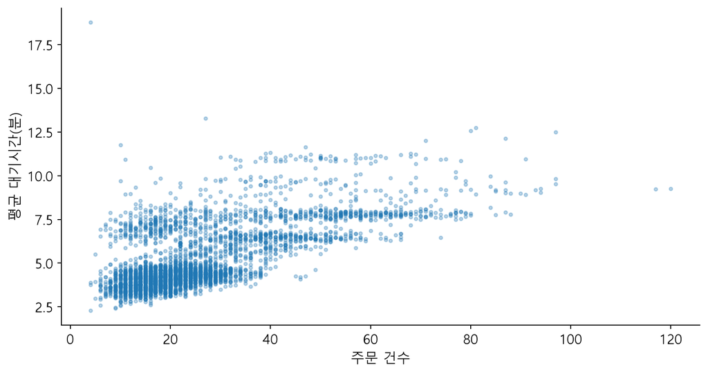

```python
plt.scatter(slot["orders"], slot["wait"], s=8, alpha=0.3)
plt.xlabel("주문 건수")
plt.ylabel("평균 대기시간(분)")
plt.show()
```

## 입력 변수와 목표 변수

1 문제 정의2 자료 준비3 모델 학습4 모델 평가5 성능 개선6 예측과 활용

```python
X = slot[["orders", "staff"]]
y = slot["wait"]
X.head(3)
```

|  | orders | staff |
| --- | --- | --- |
| 0 | 16 | 3 |
| 1 | 13 | 3 |
| 2 | 20 | 3 |

## 학습용 자료와 평가용 자료

1 문제 정의2 자료 준비3 모델 학습4 모델 평가5 성능 개선6 예측과 활용

```python
X_train, X_test, y_train, y_test = train_test_split(
    X, y, test_size=0.2, random_state=0)
print("학습용:", len(X_train), "개")
print("평가용:", len(X_test), "개")
```

```
학습용: 3120 개
평가용: 780 개
```

## 선형 회귀의 원리

1 문제 정의2 자료 준비3 모델 학습4 모델 평가5 성능 개선6 예측과 활용

예측값 = 절편 + 기울기 × 주문 건수

- 입력과 목표 변수 사이에 직선 관계가 있다고 보고 예측하는 모델입니다.
- 학습은 오차의 제곱합이 가장 작아지는 절편과 기울기를 찾는 일입니다.
- 학습이 끝나면 식에 입력을 넣어 예측합니다. 학습한 식이 평균 대기시간 = 3.20 + 0.0786 × 주문 건수일 때, 주문 50건의 예측값은 3.20 + 0.0786 × 50 ≈ 7.1분입니다.

## fit()을 이용한 모델 학습

1 문제 정의2 자료 준비3 모델 학습4 모델 평가5 성능 개선6 예측과 활용

```python
model_one = LinearRegression()
model_one.fit(X_train[["orders"]], y_train)
print("기울기:", round(model_one.coef_[0], 4))
print("절편:", round(model_one.intercept_, 2))
```

```
기울기: 0.0786
절편: 3.2
```

- 학습은 `fit(입력, 정답)` 함수가 수행합니다. 학습용 입력과 정답에서 오차가 가장 작은 기울기(`coef_`)와 절편(`intercept_`)을 계산해 모델에 저장합니다.
- 모델의 종류가 달라도 학습은 `fit()`으로 합니다.

## 학습된 회귀선

1 문제 정의2 자료 준비3 모델 학습4 모델 평가5 성능 개선6 예측과 활용

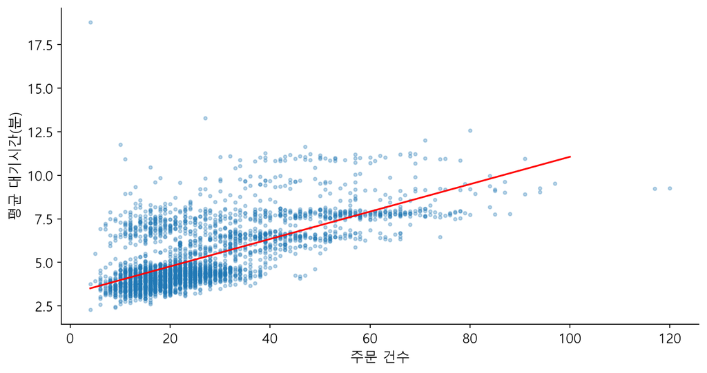

```python
x_line = pd.DataFrame({"orders": [4, 100]})
plt.scatter(X_train["orders"], y_train, s=8, alpha=0.3)
plt.plot(x_line["orders"], model_one.predict(x_line), color="red")
plt.xlabel("주문 건수")
plt.ylabel("평균 대기시간(분)")
plt.show()
```

## predict()를 이용한 예측

1 문제 정의2 자료 준비3 모델 학습4 모델 평가5 성능 개선6 예측과 활용

```python
predicted = model_one.predict(X_test[["orders"]])
result = pd.DataFrame({"주문 건수": X_test["orders"],
                       "실제": y_test, "예측": predicted})
result.head(4).round(2)
```

|  | 주문 건수 | 실제 | 예측 |
| --- | --- | --- | --- |
| 1951 | 13 | 3.49 | 4.22 |
| 1550 | 12 | 3.24 | 4.14 |
| 31 | 14 | 6.61 | 4.30 |
| 3171 | 20 | 3.80 | 4.77 |

- `predict()`는 학습한 모델에 평가용 입력만 넣어 예측값을 계산합니다. 평가용 정답은 예측값과 비교할 때만 사용합니다.

## 평균 절대 오차

1 문제 정의2 자료 준비3 모델 학습4 모델 평가5 성능 개선6 예측과 활용

```python
result["오차"] = (result["실제"] - result["예측"]).abs()
one_error = mean_absolute_error(y_test, predicted)
print(result.head(4).round(2))
print("평균 절대 오차:", round(one_error, 2), "분")
```

```
      주문 건수    실제    예측    오차
1951     13  3.49  4.22  0.73
1550     12  3.24  4.14  0.91
31       14  6.61  4.30  2.31
3171     20  3.80  4.77  0.97
평균 절대 오차: 0.97 분
```

- 오차는 실제값과 예측값 차이의 절댓값이며, 평가용 자료 전체의 오차를 평균한 값이 평균 절대 오차입니다.

## 입력 변수의 추가

1 문제 정의2 자료 준비3 모델 학습4 모델 평가5 성능 개선6 예측과 활용

```python
model_two = LinearRegression()
model_two.fit(X_train, y_train)
for name, value in zip(X_train.columns, model_two.coef_):
    print(name, "의 계수:", round(value, 3))
two_error = mean_absolute_error(y_test, model_two.predict(X_test))
print("평균 절대 오차:", round(two_error, 2), "분")
```

```
orders 의 계수: 0.104
staff 의 계수: -1.25
평균 절대 오차: 0.93 분
```

- 입력을 주문 건수 하나에서 둘로 늘리면 평균 절대 오차가 0.97분에서 0.93분으로 줄어듭니다.

## 의사결정나무의 원리

1 문제 정의2 자료 준비3 모델 학습4 모델 평가5 성능 개선6 예측과 활용

스무고개처럼 예·아니오 질문을 이어 가며 자료를 나눕니다. 맨 아래 칸에 도착하면 결과가 나옵니다.

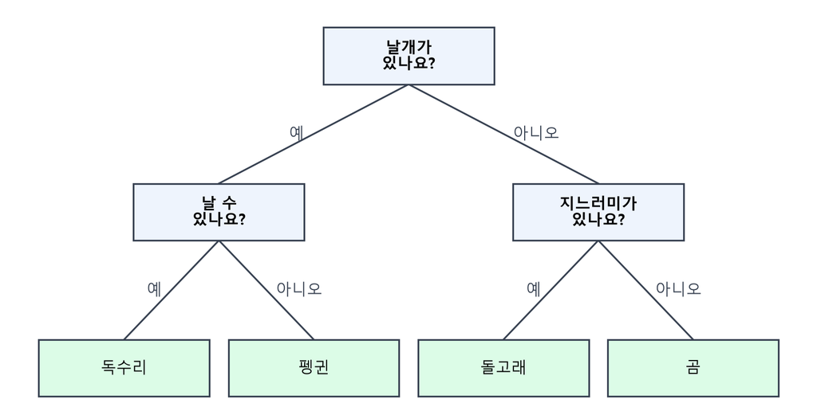

## 회귀에 쓰는 의사결정나무

1 문제 정의2 자료 준비3 모델 학습4 모델 평가5 성능 개선6 예측과 활용

숫자를 예측할 때는 맨 아래 칸에 도착한 학습용 시간대들의 **평균 대기시간**이 예측값입니다.

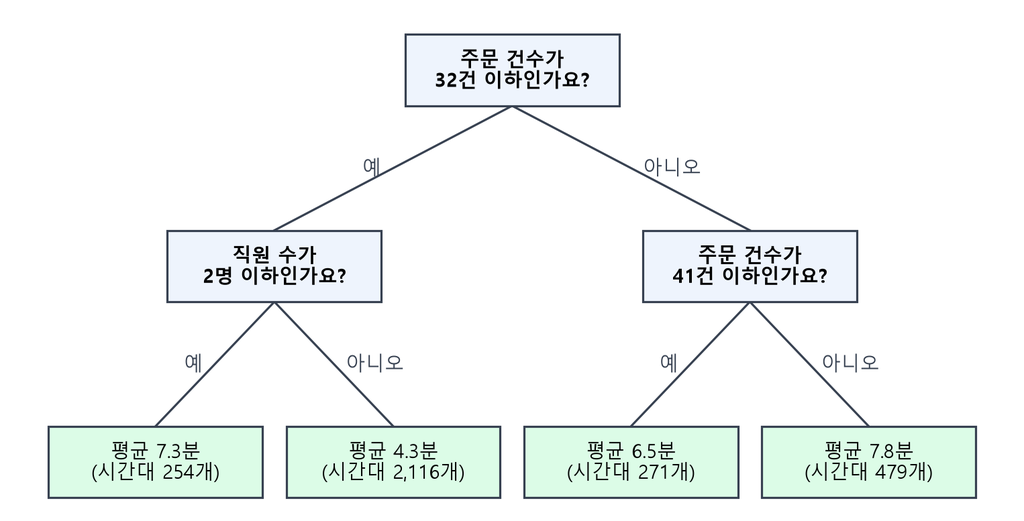

## 의사결정나무의 예측 경로

1 문제 정의2 자료 준비3 모델 학습4 모델 평가5 성능 개선6 예측과 활용

주문 25건, 직원 3명인 시간대는 위에서부터 질문에 답하며 내려가 **4.3분**으로 예측됩니다.

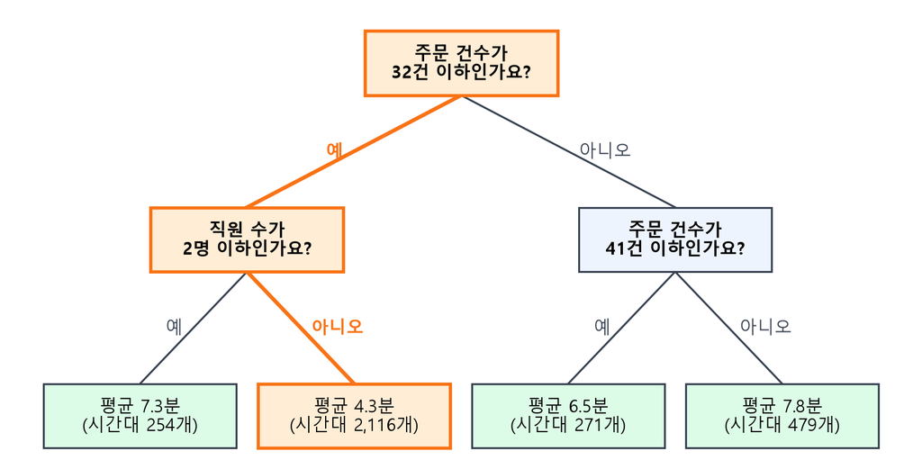

## 질문과 기준값의 선택

1 문제 정의2 자료 준비3 모델 학습4 모델 평가5 성능 개선6 예측과 활용

`fit()`이 여러 질문과 기준값을 시험해, 나눈 두 칸 안의 대기시간이 각각 칸의 평균에 가장 가깝게 모이는 질문을 고릅니다.

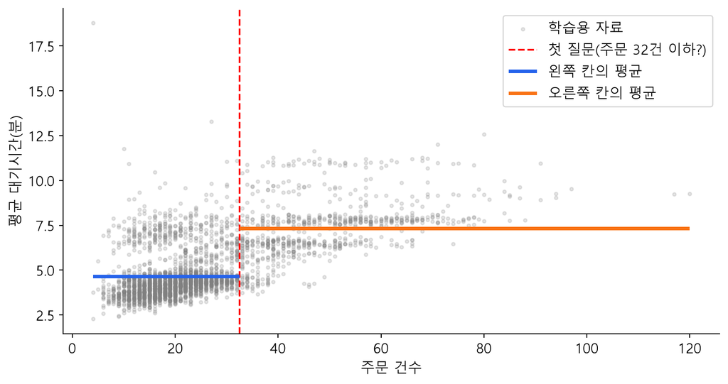

## 의사결정나무 회귀

1 문제 정의2 자료 준비3 모델 학습4 모델 평가5 성능 개선6 예측과 활용

```python
tree = DecisionTreeRegressor(max_depth=3, random_state=0)
tree.fit(X_train, y_train)
tree_error = mean_absolute_error(y_test, tree.predict(X_test))
print("평균 절대 오차:", round(tree_error, 2), "분")
```

```
평균 절대 오차: 0.66 분
```

- 모델만 바꾸었고 `fit()`과 `predict()`의 사용법은 선형 회귀와 같습니다.
- `max_depth`는 질문을 이어 가는 최대 횟수입니다.

## 의사결정나무의 구조

1 문제 정의2 자료 준비3 모델 학습4 모델 평가5 성능 개선6 예측과 활용

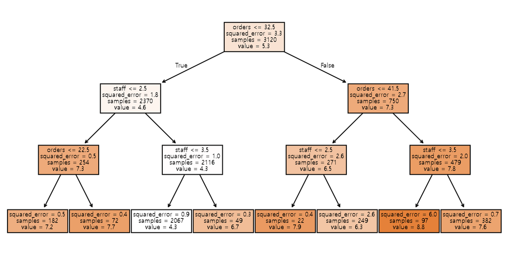

```python
plot_tree(tree, feature_names=["orders", "staff"], filled=True, precision=1)
plt.show()
```

## 나무 깊이에 따른 오차

1 문제 정의2 자료 준비3 모델 학습4 모델 평가5 성능 개선6 예측과 활용

```python
depths = [1, 2, 3, 4, 5, 10, None]
train_errors, test_errors = [], []
for depth in depths:
    m = DecisionTreeRegressor(max_depth=depth, random_state=0).fit(X_train, y_train)
    train_errors.append(mean_absolute_error(y_train, m.predict(X_train)))
    test_errors.append(mean_absolute_error(y_test, m.predict(X_test)))

pd.DataFrame({"깊이": ["1", "2", "3", "4", "5", "10", "제한 없음"],
              "학습용 오차": train_errors,
              "평가용 오차": test_errors}).set_index("깊이").round(2).T
```

| 깊이 | 1 | 2 | 3 | 4 | 5 | 10 | 제한 없음 |
| --- | --- | --- | --- | --- | --- | --- | --- |
| 학습용 오차 | 1.03 | 0.72 | 0.67 | 0.61 | 0.60 | 0.58 | 0.58 |
| 평가용 오차 | 1.00 | 0.72 | 0.66 | 0.62 | 0.62 | 0.64 | 0.64 |

- 학습용 오차는 깊이가 깊을수록 줄지만, 평가용 오차는 깊이 5에서 가장 작고 이후에는 커집니다.
- 학습용 자료에만 지나치게 맞아 새 자료에서 오차가 커지는 상태를 과적합이라고 합니다.

## 랜덤 포레스트의 원리

1 문제 정의2 자료 준비3 모델 학습4 모델 평가5 성능 개선6 예측과 활용

나무 한 그루는 학습용 자료가 달라지면 예측이 흔들립니다. 나무마다 **무작위로 다시 뽑은 자료**로 여러 그루를 만들고, 예측을 평균합니다.

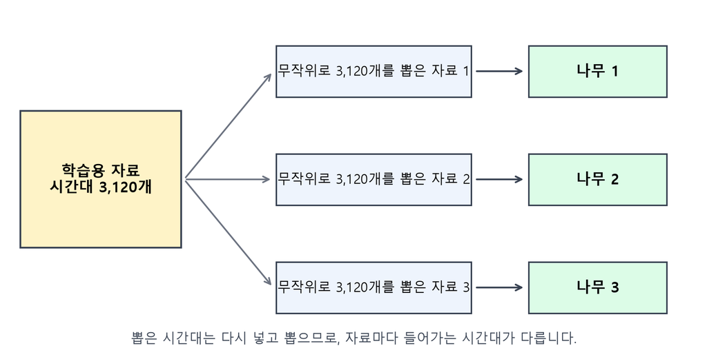

## 랜덤 포레스트의 예측 과정

1 문제 정의2 자료 준비3 모델 학습4 모델 평가5 성능 개선6 예측과 활용

같은 입력을 모든 나무에 물어보고, 나무들이 낸 예측을 평균해 최종 예측으로 합니다.

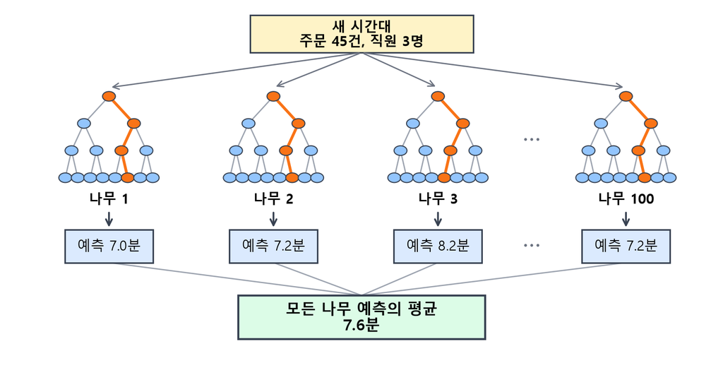

## 랜덤 포레스트 회귀

1 문제 정의2 자료 준비3 모델 학습4 모델 평가5 성능 개선6 예측과 활용

```python
forest = RandomForestRegressor(n_estimators=100, max_depth=5, random_state=0)
forest.fit(X_train, y_train)
forest_error = mean_absolute_error(y_test, forest.predict(X_test))
print("평균 절대 오차:", round(forest_error, 2), "분")
```

```
평균 절대 오차: 0.61 분
```

- `n_estimators`는 나무의 수이고, `max_depth`는 나무 한 그루의 깊이입니다.
- 사용법은 다른 모델과 같습니다. `fit()`으로 학습하고 `predict()`로 예측합니다.

## 나무 100그루의 예측 분포

1 문제 정의2 자료 준비3 모델 학습4 모델 평가5 성능 개선6 예측과 활용

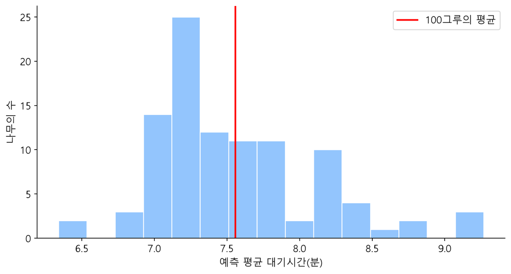

```python
tree_predictions = [one.predict(new_slot.values)[0] for one in forest.estimators_]
plt.hist(tree_predictions, bins=15, color="#93c5fd", edgecolor="white")
plt.axvline(np.mean(tree_predictions), color="red", linewidth=2, label="100그루의 평균")
plt.xlabel("예측 평균 대기시간(분)")
plt.ylabel("나무의 수")
plt.legend()
plt.show()
```

## 모델 간 평균 절대 오차의 비교

1 문제 정의2 자료 준비3 모델 학습4 모델 평가5 성능 개선6 예측과 활용

```python
best_tree = DecisionTreeRegressor(max_depth=5, random_state=0).fit(X_train, y_train)
best_error = mean_absolute_error(y_test, best_tree.predict(X_test))

pd.DataFrame({
    "모델": ["선형 회귀(주문 건수)", "선형 회귀(주문 건수, 직원 수)",
           "의사결정나무(깊이 3)", "의사결정나무(깊이 5)", "랜덤 포레스트"],
    "평균 절대 오차(분)": [one_error, two_error, tree_error, best_error, forest_error],
}).round(2)
```

|  | 모델 | 평균 절대 오차(분) |
| --- | --- | --- |
| 0 | 선형 회귀(주문 건수) | 0.97 |
| 1 | 선형 회귀(주문 건수, 직원 수) | 0.93 |
| 2 | 의사결정나무(깊이 3) | 0.66 |
| 3 | 의사결정나무(깊이 5) | 0.62 |
| 4 | 랜덤 포레스트 | 0.61 |

## 모델별 예측 곡선

1 문제 정의2 자료 준비3 모델 학습4 모델 평가5 성능 개선6 예측과 활용

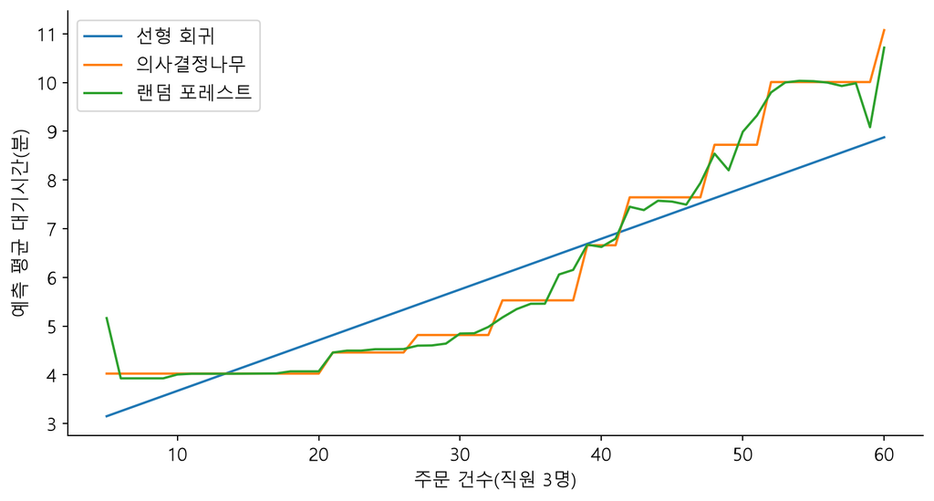

```python
grid = pd.DataFrame({"orders": np.arange(5, 61), "staff": 3})
plt.plot(grid["orders"], model_two.predict(grid), label="선형 회귀")
plt.plot(grid["orders"], best_tree.predict(grid), label="의사결정나무")
plt.plot(grid["orders"], forest.predict(grid), label="랜덤 포레스트")
plt.xlabel("주문 건수(직원 3명)")
plt.ylabel("예측 평균 대기시간(분)")
plt.legend()
plt.show()
```

## 새로운 입력에 대한 예측

1 문제 정의2 자료 준비3 모델 학습4 모델 평가5 성능 개선6 예측과 활용

```python
print("선형 회귀:", round(model_two.predict(new_slot)[0], 1), "분")
print("의사결정나무:", round(best_tree.predict(new_slot)[0], 1), "분")
print("랜덤 포레스트:", round(forest.predict(new_slot)[0], 1), "분")
```

```
선형 회귀: 7.3 분
의사결정나무: 7.6 분
랜덤 포레스트: 7.6 분
```

- 주문 45건, 직원 3명인 시간대의 평균 대기시간을 세 모델로 예측합니다.
- 정답을 모르는 새 입력에 `predict()`를 적용하는 것이 모델의 활용입니다.

## 회귀 모델 구축 절차의 요약

```python
# 1단계 문제 정의
X = slot[["orders", "staff"]]
y = slot["wait"]
# 2단계 자료 준비
X_train, X_test, y_train, y_test = train_test_split(X, y, test_size=0.2, random_state=0)
# 3단계 모델 학습
model = RandomForestRegressor(n_estimators=100, max_depth=5, random_state=0)
model.fit(X_train, y_train)
# 4단계 모델 평가
predicted = model.predict(X_test)
print("평균 오차:", round(mean_absolute_error(y_test, predicted), 2), "분")
# 5단계 성능 개선: 입력, 모델, 설정을 바꿔 3~4단계를 반복
# 6단계 예측과 활용
print("새 시간대의 예측:", round(model.predict(new_slot)[0], 1), "분")
```

```
평균 오차: 0.61 분
새 시간대의 예측: 7.6 분
```